[figure not shown]

## Demonstration Class 04

# Understanding evolutionary strategies and covariance matrix adaptation

### Luis Martí, LIRA/[DEE](http://www.ele.puc-rio.br)/[PUC-Rio](http://www.puc-rio.br)

http://lmarti.com; lmarti@ele.puc-rio.br

[Advanced Evolutionary Computation: Theory and Practice](http://lmarti.com/aec-2014)

The notebook is better viewed rendered as slides. You can convert it to slides and view them by:

- using [nbconvert](http://ipython.org/ipython-doc/1/interactive/nbconvert.html) with a command like:

  ```bash
  $ ipython nbconvert --to slides --post serve <this-notebook-name.ipynb>
  ```

- installing [Reveal.js - Jupyter/IPython Slideshow Extension](https://github.com/damianavila/live_reveal)
- using the online [IPython notebook slide viewer](https://slideviewer.herokuapp.com/) (some slides of the notebook might not be properly rendered).

This and other related IPython notebooks can be found at the course github repository:

- https://github.com/lmarti/evolutionary-computation-course

```python
import numpy
import matplotlib.pyplot as plt
import matplotlib.colors as colors
from matplotlib import cm
from mpl_toolkits.mplot3d import axes3d
from scipy.stats import norm, multivariate_normal
import math

%matplotlib inline

default_colormap = cm.PuBuGn # the default colormap that we will use for our plots
```

### Statistics recap

- [Random variable](http://en.wikipedia.org/wiki/Random_variable): a variable whose value is subject to variations due to **chance**. A random variable can take on a set of possible different values, each with an associated probability, in contrast to other mathematical variables.
- [Probability distribution](http://en.wikipedia.org/wiki/Probability_distribution): mathematical function describing the possible values of a random variable and their associated probabilities.
- [Probability density function (pdf)](http://en.wikipedia.org/wiki/Probability_density_function) of a **continuous random variable** is a function that describes the relative likelihood for this random variable to take on a given value.
  - The probability of the random variable falling within a particular range of values is given by the integral of this variable’s density over that range.
  - The probability density function is nonnegative everywhere, and its integral over the entire space is equal to one.

[figure not shown]

### Moments

The probability distribution of a random variable is often characterised by a small number of parameters, which also have a practical interpretation.

- Mean (a.k.a expected value) refers to one measure of the central tendency either of a probability distribution or of the random variable characterized by that distribution.
  - population mean: $\mu = \operatorname{E}[X]$.
  - estimation of sample mean: $\bar{x}$.
- [Standard deviation](http://en.wikipedia.org/wiki/Standard_deviation) measures the amount of variation or dispersion from the mean.
  - population deviation: $$ \sigma = \sqrt{\operatorname E[X^2]-(\operatorname E[X])^2} = \sqrt{\frac{1}{N} \sum_{i=1}^N (x_i - \mu)^2}. $$
  - unbiased estimator: $$ s^2 = \frac{1}{N-1} \sum_{i=1}^N (x_i - \overline{x})^2. $$

### Two samples

```python
sample1 = numpy.random.normal(0, 0.5, 1000)
sample2 = numpy.random.normal(1,1,500)
```

```python
def plot_normal_sample(sample, mu, sigma):
    'Plots an histogram and the normal distribution corresponding to the parameters.'
    x = numpy.linspace(mu - 4*sigma, mu + 4*sigma, 100)
    plt.plot(x, norm.pdf(x, mu, sigma), 'r', lw=2)
    plt.hist(sample, 30, normed=True, alpha=0.2)
    plt.annotate('3$\sigma$',
                     xy=(mu + 3*sigma, 0),  xycoords='data',
                     xytext=(0, 100), textcoords='offset points',
                     fontsize=15,
                     arrowprops=dict(arrowstyle="->",
                                    connectionstyle="arc,angleA=180,armA=20,angleB=90,armB=15,rad=7"))
    plt.annotate('-3$\sigma$',
                     xy=(mu -3*sigma, 0), xycoords='data',
                     xytext=(0, 100), textcoords='offset points',
                     fontsize=15,
                     arrowprops=dict(arrowstyle="->",
                                     connectionstyle="arc,angleA=180,armA=20,angleB=90,armB=15,rad=7"))
```

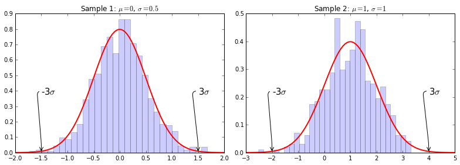

```python
plt.figure(1, figsize=(11,4))
plt.subplot(121)
plot_normal_sample(sample1, 0, 0.5)
plt.title('Sample 1: $\mu=0$, $\sigma=0.5$')
plt.subplot(122)
plot_normal_sample(sample2, 1, 1)
plt.title('Sample 2: $\mu=1$, $\sigma=1$')
plt.tight_layout()
```

```python
print('Sample 1; estimated mean:', sample1.mean(), ' and std. dev.: ', sample1.std())
print('Sample 2; estimated mean:', sample2.mean(), ' and std. dev.: ', sample2.std())
```

```
('Sample 1; estimated mean:', 0.020671837916086566, ' and std. dev.: ', 0.5065008097785525)
('Sample 2; estimated mean:', 1.0096777574435771, ' and std. dev.: ', 0.97249983678138074)
```

Covariance is a measure of how much two random variables change together. $$ \operatorname{cov}(X,Y) = \operatorname{E}{\big[(X - \operatorname{E}[X])(Y - \operatorname{E}[Y])\big]}, $$ $$ \operatorname{cov}(X,X) = s(X), $$

- The sign of the covariance therefore shows the tendency in the linear relationship between the variables.
- The magnitude of the covariance is not easy to interpret.
- The normalized version of the covariance, the correlation coefficient, however, shows by its magnitude the strength of the linear relation.

### Understanding covariance

```python
a = list(zip(sample1,numpy.ones(len(sample1))))
sample_2d = numpy.array(a).T
```

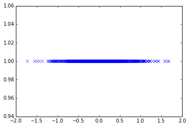

```python
plt.plot(sample_2d[0,:], sample_2d[1,:],'bx')
```

```python
numpy.cov(sample_2d) # computes covariance between the two components of the sample
```

```
array([[ 0.25679987,  0.        ],
       [ 0.        ,  0.        ]])
```

As the sample is only distributed along one axis, the covariance does not detects any relationship between them.

What happens when we rotate the sample?

```python
def rotate_sample(sample, angle=-45):
    'Rotates a sample by `angle` degrees.'
    theta = (angle/180.) * numpy.pi
    rot_matrix = numpy.array([[numpy.cos(theta), -numpy.sin(theta)],
                         [numpy.sin(theta),  numpy.cos(theta)]])
    return sample.T.dot(rot_matrix).T
```

```python
rot_sample_2d = rotate_sample(sample_2d)
```

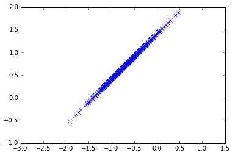

```python
plt.plot(rot_sample_2d[0,:], rot_sample_2d[1,:],'bx')
a = plt.axis('equal')
```

```python
numpy.cov(rot_sample_2d)
```

```
array([[ 0.12839994,  0.12839994],
       [ 0.12839994,  0.12839994]])
```

### A two-dimensional normally-distributed variable

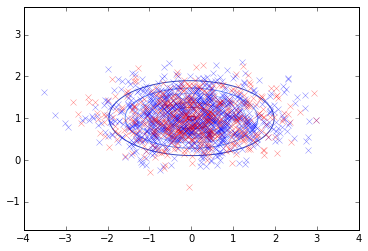

```python
mu = [0,1]
cov = [[1,0],[0,0.2]] # diagonal covariance, points lie on x or y-axis
sample = numpy.random.multivariate_normal(mu,cov,1000).T
plt.plot(sample[0], sample[1], 'bx', alpha=0.47)

estimated_mean = sample.mean(axis=1)
estimated_cov = numpy.cov(sample)
e_x,e_y = numpy.random.multivariate_normal(estimated_mean,estimated_cov,500).T

plt.plot(e_x,e_y,'rx', alpha=0.47)
x, y = numpy.mgrid[-4:4:.01, -1:3:.01]
pos = numpy.empty(x.shape + (2,))
pos[:, :, 0] = x; pos[:, :, 1] = y
rv = multivariate_normal(estimated_mean, estimated_cov)
plt.contour(x, y, rv.pdf(pos), cmap=cm.coolwarm, lw=4)
a=plt.axis('equal')
```

### This is better understood in 3D

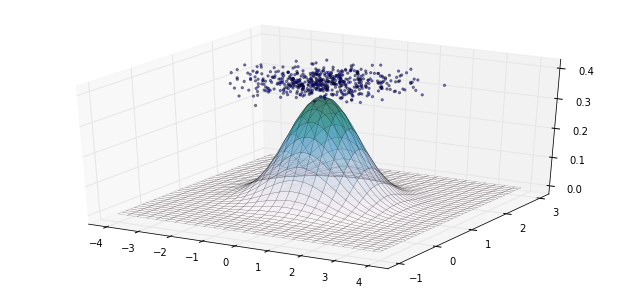

```python
fig = plt.figure(figsize=(11,5))
ax = fig.gca(projection='3d')
cset = ax.plot_surface(x, y, rv.pdf(pos), cmap=default_colormap, rstride=30, cstride=10, linewidth=0.25, alpha=0.47)
ax.scatter(e_x, e_y, 0.4, marker='.', alpha=0.47)
a = ax.axis('tight')
```

Again, what happens if we rotate the sample?

```python
rot_sample = rotate_sample(sample)
estimated_mean = rot_sample.mean(axis=1)
estimated_cov = numpy.cov(rot_sample)
e_x,e_y = numpy.random.multivariate_normal(estimated_mean,estimated_cov,500).T
```

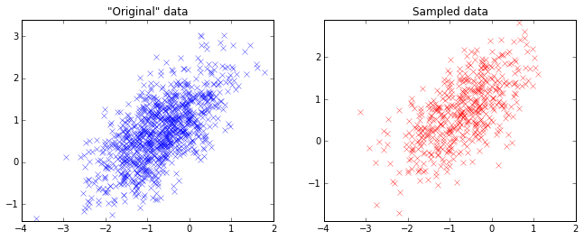

```python
fig = plt.figure(figsize=(11,4))
plt.subplot(121)
plt.plot(rot_sample[0], rot_sample[1], 'x', alpha=0.7)
plt.title('"Original" data')
plt.axis('equal')
plt.subplot(122)
plt.plot(e_x,e_y,'rx', alpha=0.7)
plt.title('Sampled data')
a = plt.axis('equal')
```

Covariance captures the dependency and can model disposition of the "original" sample.

```python
x, y = numpy.mgrid[-4:4:.01, -3:3:.01]
pos = numpy.empty(x.shape + (2,))
pos[:, :, 0] = x; pos[:, :, 1] = y
rv = multivariate_normal(estimated_mean, estimated_cov)
```

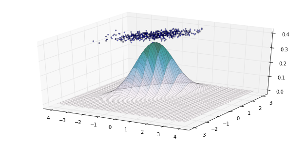

```python
fig = plt.figure(figsize=(11,5))
ax = fig.gca(projection='3d')
cset = ax.plot_surface(x, y, rv.pdf(pos), cmap=default_colormap, rstride=40, cstride=10, linewidth=0.15, alpha=0.47)
#ax.clabel(cset, fontsize=9, inline=1)
ax.scatter(e_x, e_y, 0.4, marker='.', alpha=0.47)
a= ax.axis('tight')
```

# Evolutionary Strategies

We will be using DEAP again to present some of the ES main concepts.

```python
import array
import random
import time
import copy

from deap import base, creator, benchmarks, tools, algorithms

random.seed()
```

Before we dive into the discussion lets code some support functions.

```python
def plot_problem_3d(problem, bounds, resolution=100.,
                    cmap=default_colormap, rstride=10, cstride=10,
                    linewidth=0.15, alpha=0.65, ax=None):
    'Plots a given deap benchmark problem in 3D mesh.'
    (minx,miny),(maxx,maxy) = bounds
    x_range = numpy.arange(minx, maxx, (maxx-minx)/resolution)
    y_range = numpy.arange(miny, maxy, (maxy-miny)/resolution)

    X, Y = numpy.meshgrid(x_range, y_range)
    Z = numpy.zeros((len(x_range), len(y_range)))

    for i in range(len(x_range)):
        for j in range(len(y_range)):
            Z[i,j] = problem((x_range[i], y_range[j]))[0]

    if not ax:
        fig = plt.figure(figsize=(11,6))
        ax = fig.gca(projection='3d')

    cset = ax.plot_surface(X, Y, Z, cmap=cmap, rstride=rstride, cstride=cstride, linewidth=linewidth, alpha=alpha)
```

```python
def plot_problem_controur(problem, bounds, optimum=None,
                          resolution=100., cmap=default_colormap,
                          rstride=1, cstride=10, linewidth=0.15,
                          alpha=0.65, ax=None):
    'Plots a given deap benchmark problem as a countour plot'
    (minx,miny),(maxx,maxy) = bounds
    x_range = numpy.arange(minx, maxx, (maxx-minx)/resolution)
    y_range = numpy.arange(miny, maxy, (maxy-miny)/resolution)

    X, Y = numpy.meshgrid(x_range, y_range)
    Z = numpy.zeros((len(x_range), len(y_range)))

    for i in range(len(x_range)):
        for j in range(len(y_range)):
            Z[i,j] = problem((x_range[i], y_range[j]))[0]

    if not ax:
        fig = plt.figure(figsize=(6,6))
        ax = fig.gca()
        ax.set_aspect('equal')
        ax.autoscale(tight=True)

    cset = ax.contourf(X, Y, Z, cmap=cmap, rstride=rstride, cstride=cstride, linewidth=linewidth, alpha=alpha)

    if optimum:
        ax.plot(optimum[0], optimum[1], 'bx', linewidth=4, markersize=15)
```

```python
def plot_cov_ellipse(pos, cov, volume=.99, ax=None, fc='red', ec='darkred', alpha=1, lw=1):
    ''' Plots an ellipse that corresponds to a bivariate normal distribution.
    Adapted from http://www.nhsilbert.net/source/2014/06/bivariate-normal-ellipse-plotting-in-python/'''
    from scipy.stats import chi2
    from matplotlib.patches import Ellipse

    def eigsorted(cov):
        vals, vecs = numpy.linalg.eigh(cov)
        order = vals.argsort()[::-1]
        return vals[order], vecs[:,order]

    if ax is None:
        ax = plt.gca()

    vals, vecs = eigsorted(cov)
    theta = numpy.degrees(numpy.arctan2(*vecs[:,0][::-1]))

    kwrg = {'facecolor':fc, 'edgecolor':ec, 'alpha':alpha, 'linewidth':lw}

    # Width and height are "full" widths, not radius
    width, height = 2 * numpy.sqrt(chi2.ppf(volume,2)) * numpy.sqrt(vals)
    ellip = Ellipse(xy=pos, width=width, height=height, angle=theta, **kwrg)
    ax.add_artist(ellip)
```

### Why benchmarks (test) functions?

In applied mathematics, [test functions](http://en.wikipedia.org/wiki/Test_functions_for_optimization), also known as artificial landscapes, are useful to evaluate characteristics of optimization algorithms, such as:

- Velocity of convergence.
- Precision.
- Robustness.
- General performance.

DEAP has a number of test problems already implemented. See http://deap.readthedocs.org/en/latest/api/benchmarks.html

### [Bohachevsky benchmark problem](http://deap.readthedocs.org/en/latest/api/benchmarks.html#deap.benchmarks.bohachevsky)

$$\text{minimize } f(\mathbf{x}) = \sum_{i=1}^{N-1}(x_i^2 + 2x_{i+1}^2 - 0.3\cos(3\pi x_i) - 0.4\cos(4\pi x_{i+1}) + 0.7), \mathbf{x}\in \left[-100,100\right]^n,$$

> Optimum in $\mathbf{x}=\mathbf{0}$, $f(\mathbf{x})=0$.

```python
current_problem = benchmarks.bohachevsky
```

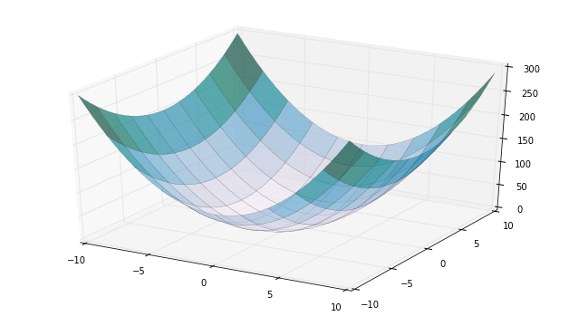

```python
plot_problem_3d(current_problem, ((-10,-10), (10,10)))
```

The Bohachevsky problem has many local optima.

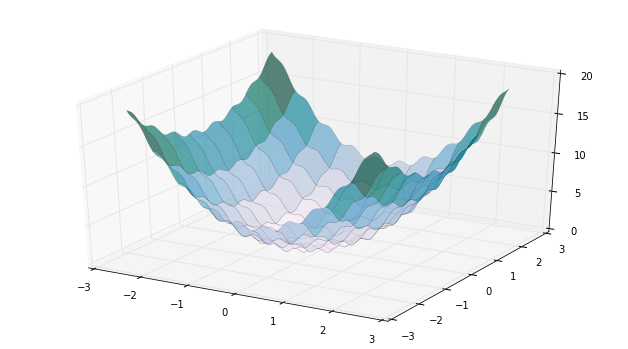

```python
plot_problem_3d(current_problem, ((-2.5,-2.5), (2.5,2.5)))
```

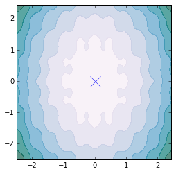

```python
ax = plt.figure().gca()
plot_problem_controur(current_problem, ((-2.5,-2.5), (2.5,2.5)), optimum=(0,0), ax=ax)
ax.set_aspect('equal')
```

## ($\mu$,$\lambda$) evolutionary strategy

Some basic initialization parameters.

```python
search_space_dims = 2 # we want to plot the individuals so this must be 2

MIN_VALUE, MAX_VALUE = -10., 10.
MIN_STRAT, MAX_STRAT = 0.0000001, 1.
```

```python
# We are facing a minimization problem
creator.create("FitnessMin", base.Fitness, weights=(-1.0,))

# Evolutionary strategies need a location (mean)
creator.create("Individual", array.array, typecode='d',
               fitness=creator.FitnessMin, strategy=None)
# ...and a value of the strategy parameter.
creator.create("Strategy", array.array, typecode="d")
```

Evolutionary strategy individuals are more complex than those we have seen so far.

They need a custom creation/initialization function.

```python
def init_univariate_es_ind(individual_class, strategy_class,
                           size, min_value, max_value,
                           min_strat, max_strat):
    ind = individual_class(random.uniform(min_value, max_value)
                           for _ in range(size))
    # we modify the instance to include the strategy in run-time.
    ind.strategy = strategy_class(random.uniform(min_strat, max_strat) for _ in range(size))
    return ind
```

```python
toolbox = base.Toolbox()
toolbox.register("individual", init_univariate_es_ind,
                 creator.Individual,
                 creator.Strategy,
                 search_space_dims,
                 MIN_VALUE, MAX_VALUE,
                 MIN_STRAT, MAX_STRAT)
toolbox.register("population", tools.initRepeat, list,
                 toolbox.individual)
```

How does an individual and a population looks like?

```python
ind = toolbox.individual()
pop = toolbox.population(n=3)
```

```python
def plot_individual(individual, ax=None):
    'Plots an ES indiviual as center and 3*sigma ellipsis.'
    cov = numpy.eye(len(individual)) * individual.strategy
    plot_cov_ellipse(individual, cov, volume=0.99, alpha=0.29, ax=ax)
    if ax:
        ax.plot(individual[0], individual[1], 'kx')
    else:
        plt.plot(individual[0], individual[1], 'kx', markersize=11)


def plot_population(pop, gen=None, max_gen=None, ax=None):
    if gen:
        plt.subplot(max_gen, 1, gen)

    for ind in pop:
        plot_individual(ind, ax)
```

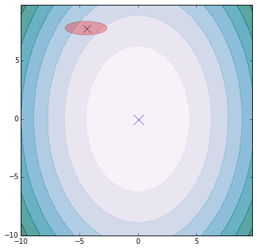

```python
plot_problem_controur(current_problem, ((-10,-10), (10,10)), optimum=(0,0))
plot_individual(ind)
```

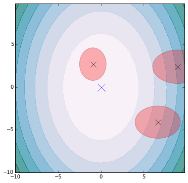

```python
plot_problem_controur(current_problem, ((-10,-10), (10,10)), optimum=(0,0))
plot_population(pop)
```

### Mutation of an evolution strategy individual according to its strategy attribute.

First the strategy is mutated according to an extended log normal rule, $$ \boldsymbol{\sigma}_t = \exp(\tau_0 \mathcal{N}_0(0, 1)) \left[ \sigma_{t-1, 1}\exp(\tau \mathcal{N}_1(0, 1)), \ldots, \sigma_{t-1, n} \exp(\tau \mathcal{N}_n(0, 1))\right], $$ with $$\tau_0 = \frac{c}{\sqrt{2n}}\text{ and }\tau = \frac{c}{\sqrt{2\sqrt{n}}}, $$

the individual is mutated by a normal distribution of mean 0 and standard deviation of $\boldsymbol{\sigma}_{t}$ (its current strategy).

A recommended choice is $c=1$ when using a $(10,100)$ evolution strategy.

```python
toolbox.register("mutate", tools.mutESLogNormal, c=1, indpb=0.1)
```

Blend crossover on both, the individual and the strategy.

```python
toolbox.register("mate", tools.cxESBlend, alpha=0.1)
toolbox.register("evaluate", current_problem)
toolbox.register("select", tools.selBest)
```

```python
mu_es, lambda_es = 3,21

pop = toolbox.population(n=mu_es)
hof = tools.HallOfFame(1)

pop_stats = tools.Statistics(key=copy.deepcopy)
pop_stats.register('pop', copy.deepcopy) # -- copies the populations themselves

pop, logbook = algorithms.eaMuCommaLambda(pop, toolbox, mu=mu_es, lambda_=lambda_es,
        cxpb=0.6, mutpb=0.3, ngen=40, stats=pop_stats, halloffame=hof, verbose=False)
```

### The final population

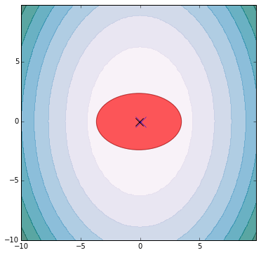

```python
plot_problem_controur(current_problem, ((-10,-10), (10,10)), optimum=(0,0))
plot_population(pop)
```

The plot (most probably) shows a "dark red" ellipse as all individuals are overlapping.

Let's see how the evolutionary process took place in animated form.

```python
from JSAnimation import IPython_display
from matplotlib import animation
```

```python
def animate(i):
    'Updates all plots to match frame _i_ of the animation.'
    ax.clear()
    plot_problem_controur(current_problem, ((-10.1,-10.1), (10.1,10.1)), optimum=(0,0), ax=ax)
    plot_population(logbook[i]['pop'], ax=ax)
    ax.set_title('$t=$' +str(i))
    return None
```

```python
fig = plt.figure(figsize=(5,5))
ax = fig.gca()
animation.FuncAnimation(fig, animate, frames=len(logbook), interval=300, blit=True)
```

[figure not shown]

Including the animation produced by the previous cell implies that the notebook becomes too large for fluent online viewing. Similary some browsers might not be capable of correctly rendering the underlying javascript.

We generate and include here a `.gif` file with the animation.

```python
anim = animation.FuncAnimation(fig, animate, frames=len(logbook), interval=300, blit=True)
anim.save('es-bohachevsky.gif', writer='imagemagick')
```

[figure not shown]

How the population progressed as the evolution proceeded?

```python
pop = toolbox.population(n=mu_es)

stats = tools.Statistics(lambda ind: ind.fitness.values)
stats.register("avg", numpy.mean)
stats.register("std", numpy.std)
stats.register("min", numpy.min)
stats.register("max", numpy.max)

pop, logbook = algorithms.eaMuCommaLambda(pop, toolbox,
                                          mu=mu_es, lambda_=lambda_es,
                                          cxpb=0.6, mutpb=0.3,
                                          ngen=40, stats=stats,
                                          verbose=False)
```

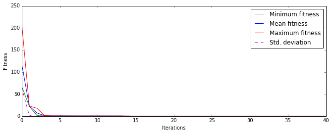

```python
plt.figure(1, figsize=(11, 4), dpi=500)
plots = plt.plot(logbook.select('min'),'g-',
                 logbook.select('avg'), 'b-',
                 logbook.select('max'), 'r-',
                 logbook.select('std'), 'm--',
                 antialiased=True)
plt.legend(plots, ('Minimum fitness', 'Mean fitness',
                   'Maximum fitness', 'Std. deviation'))
plt.ylabel('Fitness')
plt.xlabel('Iterations')
```

What happens if we increase $\mu$ and $\lambda$?

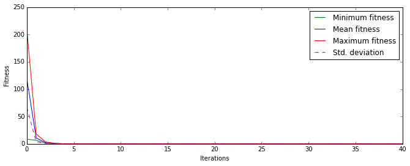

```python
mu_es, lambda_es = 10,100
pop, logbook = algorithms.eaMuCommaLambda(toolbox.population(n=mu_es), toolbox, mu=mu_es, lambda_=lambda_es,
        cxpb=0.6, mutpb=0.3, ngen=40, stats=stats, halloffame=hof, verbose=False)
plt.figure(1, figsize=(11, 4), dpi=500)
plots = plt.plot(logbook.select('min'),'g-',
                 logbook.select('avg'), 'b-',
                 logbook.select('max'), 'r-',
                 logbook.select('std'), 'm--',
                 antialiased=True)
plt.legend(plots, ('Minimum fitness', 'Mean fitness',
                   'Maximum fitness', 'Std. deviation'))
plt.ylabel('Fitness')
plt.xlabel('Iterations')
```

# Covariance Matrix Adaptation Evolutionary Strategy

- In an evolution strategy, new candidate solutions are sampled according to a multivariate normal distribution in the $\mathbb{R}^n$.
- Recombination amounts to selecting a new mean value for the distribution.
- Mutation amounts to adding a random vector, a perturbation with zero mean.
- Pairwise dependencies between the variables in the distribution are represented by a covariance matrix.

### The covariance matrix adaptation (CMA) is a method to update the covariance matrix of this distribution.

> This is particularly useful, if the objective function $f()$ is ill-conditioned.

### CMA-ES features

- Adaptation of the covariance matrix amounts to learning a second order model of the underlying objective function.
- This is similar to the approximation of the inverse Hessian matrix in the Quasi-Newton method in classical optimization.
- In contrast to most classical methods, fewer assumptions on the nature of the underlying objective function are made.
- *Only the ranking between candidate solutions is exploited* for learning the sample distribution and neither derivatives nor even the function values themselves are required by the method.

```python
from deap import cma
```

A similar setup to the previous one.

```python
creator.create("Individual", list, fitness=creator.FitnessMin)
toolbox = base.Toolbox()
toolbox.register("evaluate", current_problem)
```

We will place our start point by hand at $(5,5)$.

```python
cma_es = cma.Strategy(centroid=[5.0]*search_space_dims, sigma=5.0, lambda_=5*search_space_dims)
toolbox.register("generate", cma_es.generate, creator.Individual)
toolbox.register("update", cma_es.update)

hof = tools.HallOfFame(1)
stats = tools.Statistics(lambda ind: ind.fitness.values)
stats.register("avg", numpy.mean)
stats.register("std", numpy.std)
stats.register("min", numpy.min)
stats.register("max", numpy.max)

# The CMA-ES algorithm converge with good probability with those settings
pop, logbook = algorithms.eaGenerateUpdate(toolbox, ngen=60, stats=stats,
                                           halloffame=hof, verbose=False)

print("Best individual is %s, fitness: %s" % (hof[0], hof[0].fitness.values))
```

```
Best individual is [-1.4715208100232105e-08, 5.8262937636281469e-09], fitness: (4.2188474935755949e-15,)
```

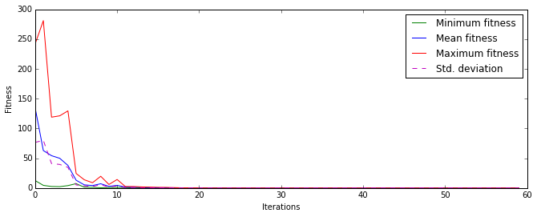

```python
plt.figure(1, figsize=(11, 4), dpi=500)
plots = plt.plot(logbook.select('min'),'g-',
                 logbook.select('avg'), 'b-',
                 logbook.select('max'), 'r-',
                 logbook.select('std'), 'm--',
                 antialiased=True)

plt.legend(plots, ('Minimum fitness', 'Mean fitness',
                   'Maximum fitness', 'Std. deviation'))
plt.ylabel('Fitness')
plt.xlabel('Iterations')
```

### OK, but wouldn't it be nice to have an animated plot of how CMA-ES progressed?

- We need to do some coding to make this animation work.
- We are going to create a class named `PlotableStrategy` that inherits from `deap.cma.Strategy`. This class logs the features we need to make the plots as evolution takes place. That is, for every iteration we store:
  - Current centroid and covariance ellipsoid.
  - Updated centroid and covariance.
  - Sampled individuals.
  - Evolution path.

*Note*: I think that DEAP's implementation of CMA-ES has the drawback of storing information that should be stored as part of "individuals". I leave this for an afternoon hack.

```python
from math import sqrt, log, exp
class PlotableStrategy(cma.Strategy):
    """This is a modification of deap.cma.Strategy class.
    We store the execution data in order to plot it.
    **Note:** This class should not be used for other uses than
    the one it is meant for."""

    def __init__(self, centroid, sigma, **kargs):
        """Does the original initialization and then reserves
        the space for the statistics."""
        super(PlotableStrategy, self).__init__(centroid, sigma, **kargs)

        self.stats_centroids = []
        self.stats_new_centroids = []
        self.stats_covs = []
        self.stats_new_covs = []
        self.stats_offspring = []
        self.stats_offspring_weights = []
        self.stats_ps = []

    def update(self, population):
        """Update the current covariance matrix strategy from the
        *population*.

        :param population: A list of individuals from which to update the
                           parameters.
        """
        # -- store current state of the algorithm
        self.stats_centroids.append(copy.deepcopy(self.centroid))
        self.stats_covs.append(copy.deepcopy(self.C))


        population.sort(key=lambda ind: ind.fitness, reverse=True)

        # -- store sorted offspring
        self.stats_offspring.append(copy.deepcopy(population))

        old_centroid = self.centroid
        self.centroid = numpy.dot(self.weights, population[0:self.mu])

        # -- store new centroid
        self.stats_new_centroids.append(copy.deepcopy(self.centroid))

        c_diff = self.centroid - old_centroid


        # Cumulation : update evolution path
        self.ps = (1 - self.cs) * self.ps \
             + sqrt(self.cs * (2 - self.cs) * self.mueff) / self.sigma \
             * numpy.dot(self.B, (1. / self.diagD) \
                          * numpy.dot(self.B.T, c_diff))

        # -- store new evol path
        self.stats_ps.append(copy.deepcopy(self.ps))

        hsig = float((numpy.linalg.norm(self.ps) /
                sqrt(1. - (1. - self.cs)**(2. * (self.update_count + 1.))) / self.chiN
                < (1.4 + 2. / (self.dim + 1.))))

        self.update_count += 1

        self.pc = (1 - self.cc) * self.pc + hsig \
                  * sqrt(self.cc * (2 - self.cc) * self.mueff) / self.sigma \
                  * c_diff

        # Update covariance matrix
        artmp = population[0:self.mu] - old_centroid
        self.C = (1 - self.ccov1 - self.ccovmu + (1 - hsig) \
                   * self.ccov1 * self.cc * (2 - self.cc)) * self.C \
                + self.ccov1 * numpy.outer(self.pc, self.pc) \
                + self.ccovmu * numpy.dot((self.weights * artmp.T), artmp) \
                / self.sigma**2

        # -- store new covs
        self.stats_new_covs.append(copy.deepcopy(self.C))

        self.sigma *= numpy.exp((numpy.linalg.norm(self.ps) / self.chiN - 1.) \
                                * self.cs / self.damps)

        self.diagD, self.B = numpy.linalg.eigh(self.C)
        indx = numpy.argsort(self.diagD)

        self.cond = self.diagD[indx[-1]]/self.diagD[indx[0]]

        self.diagD = self.diagD[indx]**0.5
        self.B = self.B[:, indx]
        self.BD = self.B * self.diagD
```

It is now possible to use/test our new class.

```python
toolbox = base.Toolbox()
toolbox.register("evaluate", current_problem)
```

```python
max_gens = 40
cma_es = PlotableStrategy(centroid=[5.0]*search_space_dims, sigma=1.0, lambda_=5*search_space_dims)
toolbox.register("generate", cma_es.generate, creator.Individual)
toolbox.register("update", cma_es.update)

# The CMA-ES algorithm converge with good probability with those settings
a = algorithms.eaGenerateUpdate(toolbox, ngen=max_gens, verbose=False)
```

Me can now code the `animate_cma_es()` function.

```python
norm=colors.Normalize(vmin=numpy.min(cma_es.weights), vmax=numpy.max(cma_es.weights))
sm = cm.ScalarMappable(norm=norm, cmap=plt.get_cmap('gray'))
```

```python
def animate_cma_es(gen):
    ax.cla()
    plot_problem_controur(current_problem, ((-11,-11), (11,11)), optimum=(0,0), ax=ax)

    plot_cov_ellipse(cma_es.stats_centroids[gen], cma_es.stats_covs[gen], volume=0.99, alpha=0.29, ax=ax)
    ax.plot(cma_es.stats_centroids[gen][0], cma_es.stats_centroids[gen][1], 'ro', markeredgecolor = 'none', ms=10)

    plot_cov_ellipse(cma_es.stats_new_centroids[gen], cma_es.stats_new_covs[gen], volume=0.99,
                     alpha=0.29, fc='green', ec='darkgreen', ax=ax)
    ax.plot(cma_es.stats_new_centroids[gen][0], cma_es.stats_new_centroids[gen][1], 'go', markeredgecolor = 'none', ms=10)

    for i in range(gen+1):
        if i == 0:
            ax.plot((0,cma_es.stats_ps[i][0]),
                     (0,cma_es.stats_ps[i][1]), 'b--')
        else:
            ax.plot((cma_es.stats_ps[i-1][0],cma_es.stats_ps[i][0]),
                     (cma_es.stats_ps[i-1][1],cma_es.stats_ps[i][1]),'b--')

    for i,ind in enumerate(cma_es.stats_offspring[gen]):
        if i < len(cma_es.weights):
            color = sm.to_rgba(cma_es.weights[i])
        else:
            color= sm.to_rgba(norm.vmin)
        ax.plot(ind[0], ind[1], 'o', color = color, ms=5, markeredgecolor = 'none')

    ax.set_ylim((-10,10))
    ax.set_xlim((-10,10))
    ax.set_title('$t=$' +str(gen))
```

### CMA-ES progress

```python
fig = plt.figure(figsize=(6,6))
ax = fig.gca()
animation.FuncAnimation(fig, animate_cma_es, frames=max_gens, interval=300, blit=True)
```

[figure not shown]

- Current centroid and covariance: **red**.
- Updated centroid and covariance: **green**.
- Sampled individuals: **shades of gray representing their corresponding weight**.
- Evolution path: **blue line starting in (0,0)**.

As some browsers might not be capable of correctly rendering the underlying javascript, we generate and include here a `.gif` file with the animation.

```python
anim = animation.FuncAnimation(fig, animate_cma_es, frames=max_gens, interval=300, blit=True)
anim.save('cma-es-bohachevsky.gif', writer='imagemagick')
```

[figure not shown]

## Homework

1. Make an animated plot with the covariance update process. You can rely on the notebook of the previous demonstration class.
2. Compare ES, CMA-ES and a genetic algortihm.
3. How do you think that evolutionary strategies and CMA-ES should be modified in order to cope with combinatorial problems?
4. How can evolution strategies be improved?